# Data wrangling

Ben Whalley

November 2021

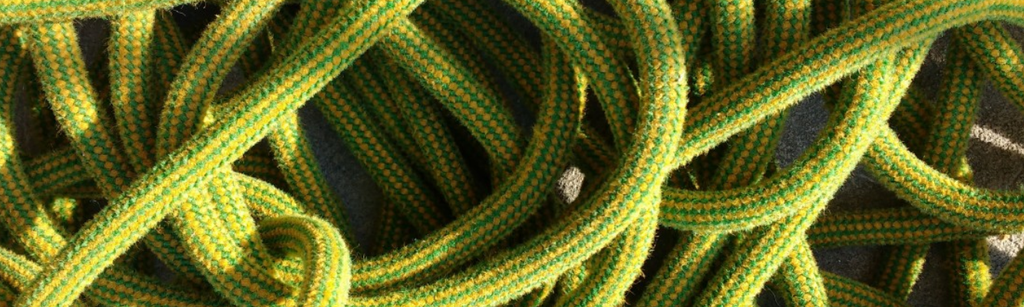

> Most time in data analysis is spent ‘tidying up’ data: getting it into a suitable format to get started. Data scientists have a particular definition of *tidy*: Tidy datasets are “easy to manipulate, model and visualize, and have a specific structure: each variable is a column, each observation is a row” (Wickham 2014).

> It’s often not convenient for humans to *enter* data in a tidy way, so untidy data is probably more common than tidy data in the wild. But doing good, reproducible science demands that we document each step of our processing in a way that others can check or repeat in future. Tools like R make this easier.

# Overview

In the [lifesavR worksheets](http://benwhalley.github.io/lifesavR/) we used various commands from the `tidyverse`, like `filter` and `group_by`.

If you want to recap these commands you could use [the cheatsheet](https://plymouthpsychology.github.io/cheatR/lifesavr_cheatsheet.html), especially the part on groups and summaries.

1. ‘Pivoting’ or reshaping data from long to wide formats (or the reverse)
2. Adding meaningful labels to categorical variables

# Before you start

Make a new `rmd` file in your datafluency directory, called `data-wrangling.rmd` and record your work in this for the next 2 sessions.

# Selecting columns

The `fuel` data also contains variables for weight and power.

We can select just these columns and save them to a smaller dataframe like this:

```r
carperformance <- fuel %>% select(mpg, weight, power)
```

#### Explanation of the commands

- On the far left we have the name of the new variable which we will create: `carperformance`.
- We can tell this will be a new variable because the `<-` symbol is just to the right, pointing at it.
- To see what `carperformance` contains, look to the right of the `<-`. We pipe the `fuel` data to the `select` command, which selects the`mpg`,`weight`, and`power` columns.

#### Explanation of the result

When running the command you won’t see any output — but a new object was created called `carperformance` which contained copies of the columns from `fuel` we selected.

We can see the first few rows of our new smaller dataframe like this:

```r
carperformance %>% head()
```

```
   mpg weight power
1 21.0   1188   110
2 21.0   1304   110
3 22.8   1052    93
4 21.4   1458   110
5 18.7   1560   175
6 18.1   1569   105
```

Try selecting columns in a dataset for yourself:

- Use any of the built in dataset, creating a copy with just a subset of 3 of its columns.

# Pivoting longer

Data is commonly stored in either [*wide* or *long* format](https://www.theanalysisfactor.com/wide-and-long-data/).

If you used SPSS to do a *t*-test or ANOVA during your undergraduate degree, you likely stored and analysed the data in **wide** format.

In wide format, each row represents the *observations from a single participant*. Each measurement for a given participant are stored in separate columns.

This is often called **row per subject** data. An example is the built in `attitude` dataset:

```r
attitude %>%
  head()
```

```
  rating complaints privileges learning raises critical advance
1     43         51         30       39     61       92      45
2     63         64         51       54     63       73      47
3     71         70         68       69     76       86      48
4     61         63         45       47     54       84      35
5     81         78         56       66     71       83      47
6     43         55         49       44     54       49      34
```

**Explanation**: Each row contains scores for a particular employee on various measures. To find out more about these data you can type `?attitude` into the console.

Let’s say we want a single plot of all these variables, something like this:

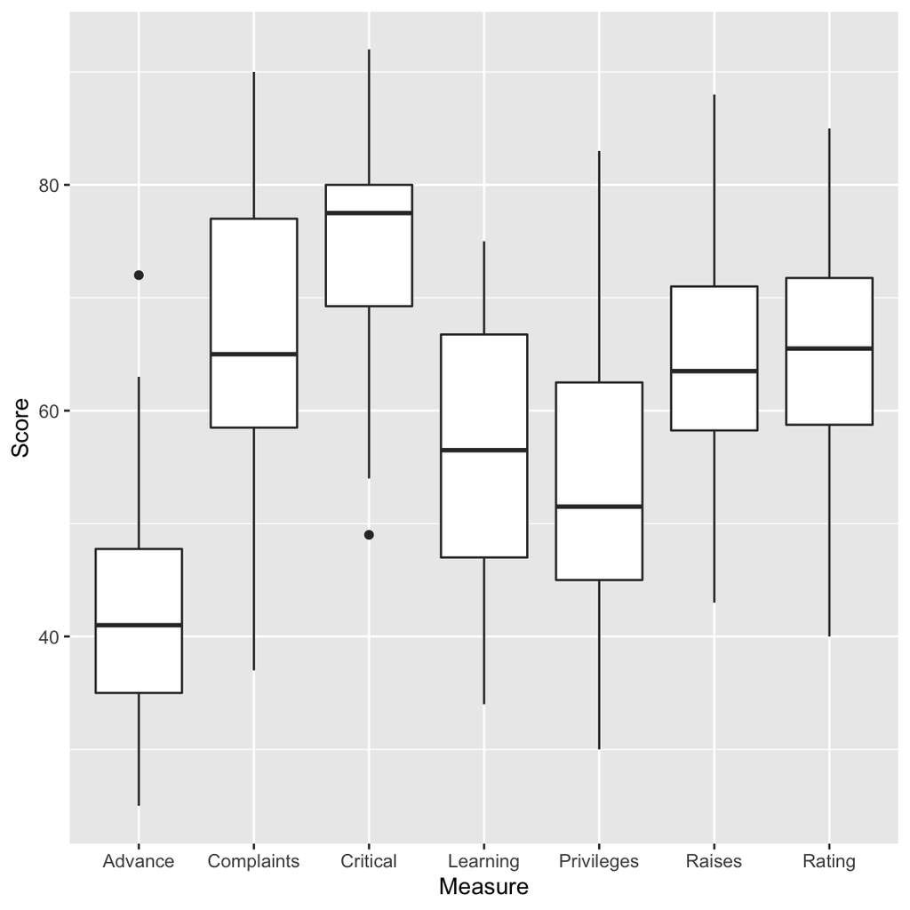

To do this we first need to convert the data to *long* format. In **long format**, each observation is saved in its own row, rather than across multiple columns.

It’s often called **“row per observation”** data.

### Using `pivot_longer()`

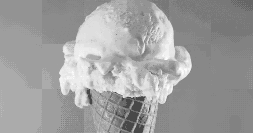

Another term used is `melting` the data img: [TrueWarrior](https://www.reddit.com/r/gifs/comments/ppam4/ice_cream_melting_and_remelting/)

> Pivoting is where you take a long data file (lots of rows, few columns) and make it wider. Or where you take a wide data file (lots of columns, few rows) and make it longer.

[video not shown]

We can convert from wide to long using the `pivot_longer()` function, as shown in the video:

To see why the function is called ‘pivot_**longer**’, imagine trying to reshape just the first two rows of the attitude dataset:

```
  rating complaints privileges learning raises critical advance
1     43         51         30       39     61       92      45
2     63         64         51       54     63       73      47
```

If we use `pivot_longer` on this selection, we end up with this:

```r
attitude %>%
  head(2) %>%
  pivot_longer(everything())
```

```
# A tibble: 14 × 2
   name       value
   <chr>      <dbl>
 1 rating        43
 2 complaints    51
 3 privileges    30
 4 learning      39
 5 raises        61
 6 critical      92
 7 advance       45
 8 rating        63
 9 complaints    64
10 privileges    51
11 learning      54
12 raises        63
13 critical      73
14 advance       47
```

**Explanation of the command**: - We selected a subset of columns and rows. - Then we used `pivot_longer(everything())` to make this into long form data. - The `everything()` part tells R to merge values from all of the columns into a single new column called `value`, and to keep track of the original variable name in a new column called `name`)

The change works like like this:

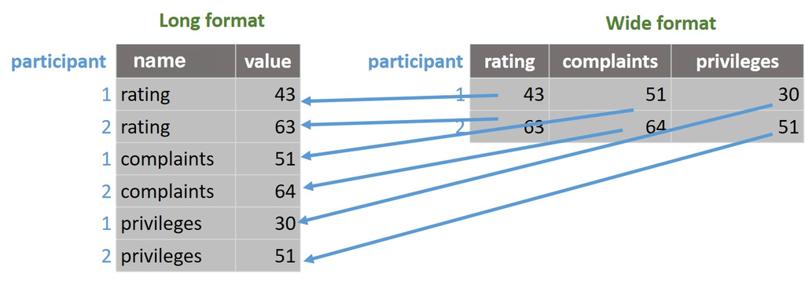

Converting from wide format to long format

You might have spotted a problem though: We don’t have a record of which participant was which in the `attitude` dataset.

This is because the mapping to participants was implicit: **each row was a different participant, but participant numbers was not actually recorded in the file**.

We can create an explicit participant identifier by adding a new column. For this we use the `mutate` and `row_number()` functions:

```r
attitude_with_person <- attitude %>%
  mutate(person = row_number()) %>%
  head(2)

attitude_with_person
```

```
  rating complaints privileges learning raises critical advance person
1     43         51         30       39     61       92      45      1
2     63         64         51       54     63       73      47      2
```

Now we have a column called `person` which stores the row number.

**But** this means if we `pivot_longer()` again, we will need to tell R *which* columns we would like to pivot.

If we don’t do this then the `person` column gets melted with everything else so we lose track of which response belonged to which participant, like this:

```r
attitude_with_person %>%
  pivot_longer(everything())
```

```
# A tibble: 16 × 2
   name       value
   <chr>      <dbl>
 1 rating        43
 2 complaints    51
 3 privileges    30
 4 learning      39
 5 raises        61
 6 critical      92
 7 advance       45
 8 person         1
 9 rating        63
10 complaints    64
11 privileges    51
12 learning      54
13 raises        63
14 critical      73
15 advance       47
16 person         2
```

**Explanation of the output** Because we didn’t tell `pivot_longer` which columns we wanted to pivot, it put all the values into a single new column called `value`. This included our participant identifier, `person` which is not what we wanted.

We can exclude `person` from the pivoting by writing:

```r
attitude_with_person %>%
  pivot_longer(-person) %>%
  head()
```

```
# A tibble: 6 × 3
  person name       value
   <int> <chr>      <dbl>
1      1 rating        43
2      1 complaints    51
3      1 privileges    30
4      1 learning      39
5      1 raises        61
6      1 critical      92
```

**Explanation of the command and output**: - Here, we still use `pivot_longer` but this time we put `-person` between the parentheses. - The minus sign, `-`, means *don’t include this variable*, so `-person` ends up meaning *include all columns except `person`*, which is what we wanted. - The output now retains the `person` column, but pivots the other variables. - This means we can tell which person provided each datapoint.

Use some tidyverse commands you already know (e.g. `select`), plus `pivot_longer`, to produce this plot using the `attitude` dataset:

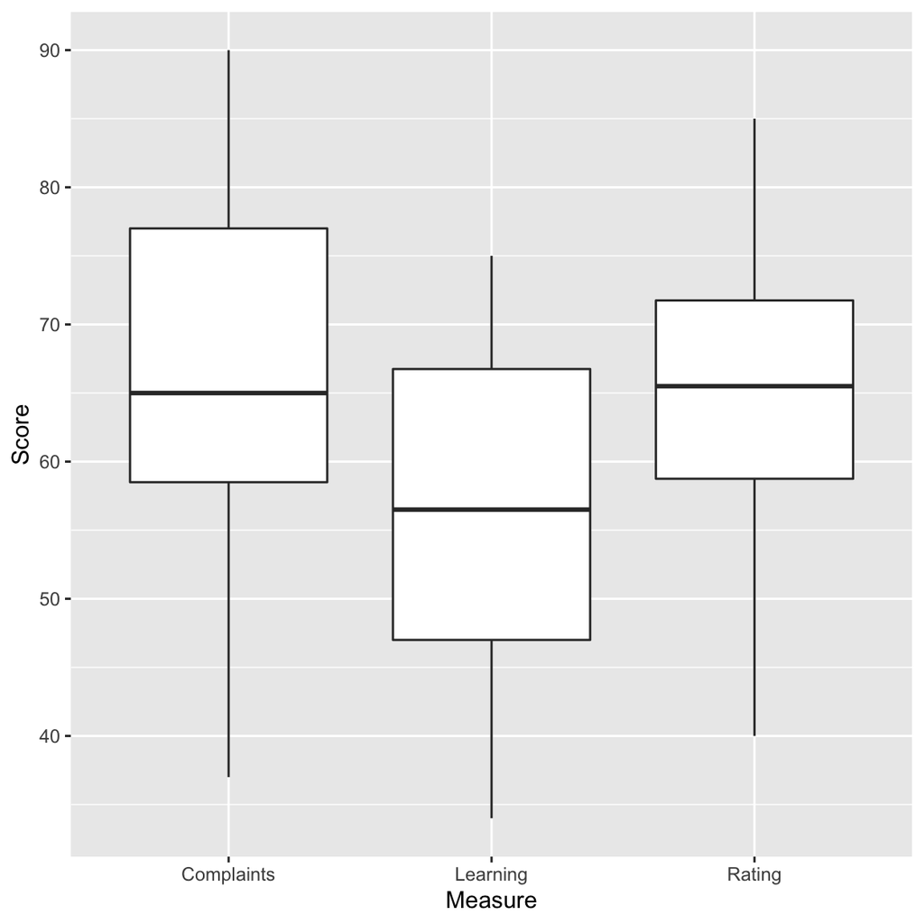

- Check the [cheatsheet](https://plymouthpsychology.github.io/cheatR/complete-cheat.html) if you get stuck
- You need to select only the three variables shown
- It’s not necessary to create a person identifier for this plot (although it won’t hurt if you do)

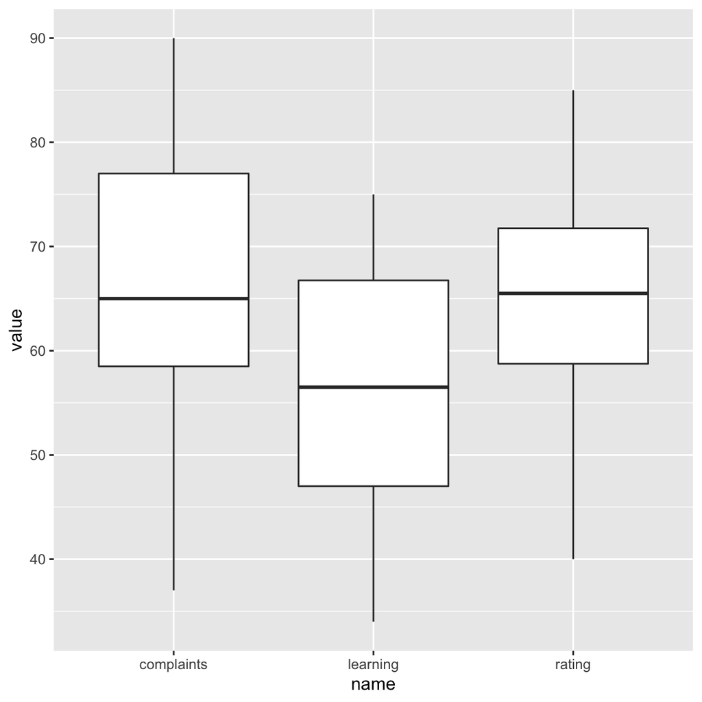

```r
attitude %>%
  select(rating, complaints, learning) %>%
  pivot_longer(everything()) %>%
  ggplot(aes(name, value)) +
  geom_boxplot()
```

# Pivoting to make summary tables

Imagine we want a table of the mean score for each question in the attitude dataset.

This would be fiddly if we just tried to use `summarise` on wide format data. But if we use `pivot_longer`, `group_by` and then `summarise` (in that order) it’s possible to take the data and make a table like this with 3 instructions to R:

```
# A tibble: 7 × 3
  Name        Mean    SD
  <chr>      <dbl> <dbl>
1 advance     42.9 10.3
2 complaints  66.6 13.3
3 critical    74.8  9.89
4 learning    56.4 11.7
5 privileges  53.1 12.2
6 raises      64.6 10.4
7 rating      64.6 12.2
```

Combine the `pivot_longer`, `group_by` and `summarise` commands (in that order) to reproduce the table above.

- You want to pivot *all* of the variables in the `attitude` dataset this time
- We covered using `summarise` in the [third `lifesavR` session here](https://benwhalley.github.io/lifesavR/session-3.html#groupby).

We might also want to produce summary statistics per-participant.

Using the commands shown above (and remembering to make a new column to store the participant number with `row_number()`), reproduce this table:

| person | mean(value) |
| --- | --- |
| 1 | 51.57 |
| 2 | 59.29 |
| 3 | 69.71 |
| 4 | 55.57 |
| 5 | 68.86 |

To make the table you will need to use the following functions, in roughly this order:

- mutate
- filter
- pivot_longer
- group_by
- summarise
- pander

```r
attitude %>%
  mutate(person = row_number()) %>%
  filter(person < 6) %>%
  pivot_longer(-person) %>%
  group_by(person) %>%
  summarise(mean(value)) %>%
  pander()
```

# Pivoting wider

Sometimes we have the opposite problem: We have long data, but want it in wide format. For example, we might want a table where it’s easy to compare between different years, like this:

```r
development %>%
  filter(year > 1990) %>%
  pivot_wider(id_cols=country,
              names_from=year,
              values_from=gdp_per_capita) %>%
  head(3) %>%
  pander::pander("GDP per-capita in 3 countries in 4 different years, from the development dataset.")
```

GDP per-capita in 3 countries in 4 different years, from the development dataset.

| country | 1992 | 1997 | 2002 | 2007 |
| --- | --- | --- | --- | --- |
| Afghanistan | 649.3 | 635.3 | 726.7 | 974.6 |
| Albania | 2497 | 3193 | 4604 | 5937 |
| Algeria | 5023 | 4797 | 5288 | 6223 |

**Instead of making the data longer, now we want to `pivot_wider`.**

The `development` data is a fairly long format. There are multiple rows per-country corresponding to different years.

We want to *compare* GDP in different *years*.

We first need to select the data we want — `country`, `year` and `GDP`, for the years after 1990:

```r
development1990s <- development %>%
  select(country, year, gdp_per_capita) %>%
  filter(year >= 1990)
```

Then we can `pivot_wider()`:

```r
development1990s %>%
  pivot_wider(
    names_from = year,
    values_from = gdp_per_capita
  ) %>%
  head()
```

```
# A tibble: 6 × 5
  country     `1992` `1997` `2002` `2007`
  <fct>        <dbl>  <dbl>  <dbl>  <dbl>
1 Afghanistan   649.   635.   727.   975.
2 Albania      2497.  3193.  4604.  5937.
3 Algeria      5023.  4797.  5288.  6223.
4 Angola       2628.  2277.  2773.  4797.
5 Argentina    9308. 10967.  8798. 12779.
6 Australia   23425. 26998. 30688. 34435.
```

Use the `funimagery` dataset in `psydata` and perform the following:

- use `select` to make a dataset with `intervention` and each of the `kg1` to `kg3` columns
- Use `pivot_longer`, `group_by` and `summarise` to calculate the average weight of participants at each timepoint
- Adapt the `group_by` function to calculate the mean at each timepoint *for each group separately*
- Add `pivot_wider` to the end of your code to create a separate column for each group.

When you finish your data should look like this:

```
# A tibble: 3 × 3
# Groups:   name [3]
  name     MI   FIT
  <chr> <dbl> <dbl>
1 kg1    89.9  91.5
2 kg2    88.6  86.4
3 kg3    88.5  84.0
```

```r
funimagery %>%
  select(intervention, kg1, kg2, kg3) %>%
  pivot_longer(-intervention) %>%
  group_by(name, intervention) %>%
  summarise(M=mean(value)) %>%
  pivot_wider(names_from=intervention, values_from=M)
```

# Using RMarkdown

Watch this video on making tables and knitting your RMarkdown document.

[video not shown]

Create an RMarkdown document (if you haven’t already) to save your work from today’s session.

- Knit this document to HTML format, and as a PDF.
- Try opening the HTML document in Word.

This video shows how to control the output in an RMarkdown document:

[video not shown]

- Try using the `echo` and `results` chunk options in your RMarkdown document. Knit each time, and note the changes.
- Make a figure using ggplot. Change the `fig.width` and `fig.height` values to note the change to the output.

Check these resources:

- [Markdown ‘cheatsheet’](https://commonmark.org/help/)
- Do the ‘10 minute markdown’ tutorial here: https://commonmark.org/help/tutorial/

Try using some of the markdown formatting to structure your own document. Knit the document as you make changes and note the results.

Wickham, Hadley. 2014. “Tidy Data.” *Journal of Statistical Software* 59 (1): 1–23. https://doi.org/10.18637/jss.v059.i10.